# Informe hito 2

@saguerraty @Bastyz @HaineAnn

October 6, 2019

# Avance Hito 2

```
## [1] "C:/Users/sague/Documents/GitHub/intro_mineria_dcc_2019/proyecto"
```

## Contexto y motivación

El proyecto se propone resolver determinar si con las herramientas del curso “Es posible mejorar el sistema de determinación de alerta ambiental en Santiago”, específicamente: ‘Cómo determinan los factores medio ambientales observables el nivel de material particulado en Santiago’"

El valor que presenta encontrar una mejora en el método utilizado para determinar una categoría de alerta ambiental va en:

1- Cuantificar el efecto de las variables utilizadas en la determinación de una situación de alerta ambientas (considerando algún grado de interpretabilidad en el modelo utilizado, esto no se mantiene para algo como un clasificador con un perceptron multicapa)

2- La disminución de la carga laboral en HH asignada a determinar una situación de alerta o emergencia ambiental, ya que la aplicación del modelo técnicamente se puede automatizar.

3- La mejora en la planificación de la ciudadanía al permitir advertir una situación de emergencia ambiental mediante regresores y luego el clasificador, con más anticipación de lo que se hace actualmente, es decir, se podría advertir con anticipación cuando hay una alta probabilidad de que se decrete una emergencia ambiental.

## Datos

Los datos utilizados durante el proyecto están almacenados y disponibles de manera pública por el Centro de investigación para el clima y la resiliencia (CR2) en el caso de los datos atmosféricos y de temperatura, y en datos.gob.cl para el caso del los datos de contaminación atmosférica pertenecientes al SINCA (MMA) , mientras que la etiqueta del modelo se obtiene mediante ‘scrapping’ del reporte diario de la situación de alerta ambiental en la página del Ministerio de medio ambiente (http://airesantiago.gob.cl/balance-1997-2017/calidad-del-aire/).

### Catacterización de los datos

Los datos están compuestos por fecha, valor de las distintas mediciones y la categorización del estado del aire; la fecha se encuentre en el formato AAAA-MM-DD como también en columnas separadas; las distintas medidas se encuentran en valores numéricos y la categorización se encuentra en formato de texto.

```r
head(tabla, n= 3L)
```

```
##        Fecha anno mes dia      O3    MP10       CO     SO2 MP25 NO2 Tmedia
## 1 2015-04-01 2015   4   1 21.9148 82.7500 0.387774 2.69379   NA  NA   19.1
## 2 2015-04-02 2015   4   2 19.7134 84.1666 0.341386 2.76313   NA  NA   18.1
## 3 2015-04-03 2015   4   3 16.8208 41.5435 0.128559 2.62000   NA  NA   16.4
##   Tmax Precipitaciones cat_mp10 cat_mp25
## 1 30.6               0    BUENO    BUENO
## 2 28.9               0    BUENO    BUENO
## 3 27.1               0    BUENO    BUENO
```

A continuación se muestra la curva ROC para un modelo de regrasión multinomial sobre dos subset de relación 70-30.

```r
tabla_ss= subset(tabla, select = -c(MP10,MP25))
# tabla_ss$cat_mp10[tabla_ss$cat_mp10=="PREEMERGENCIA"]<-"PRE EMERGENCIA"

tabla_ss$cat_mp10<- as.factor(tabla_ss$cat_mp10)
train_ind=sample(seq_len(nrow(tabla)),size = nrow(tabla)*0.7)
tabla_learn = tabla_ss[train_ind,]
tabla_test = tabla_ss[-train_ind,]

tabla_learn$cat_mp10=relevel(tabla_learn$cat_mp10, ref = "REGULAR")
mod_multi_log=multinom(cat_mp10~O3+CO+Tmedia+Tmax+Precipitaciones, data = tabla_learn)
```

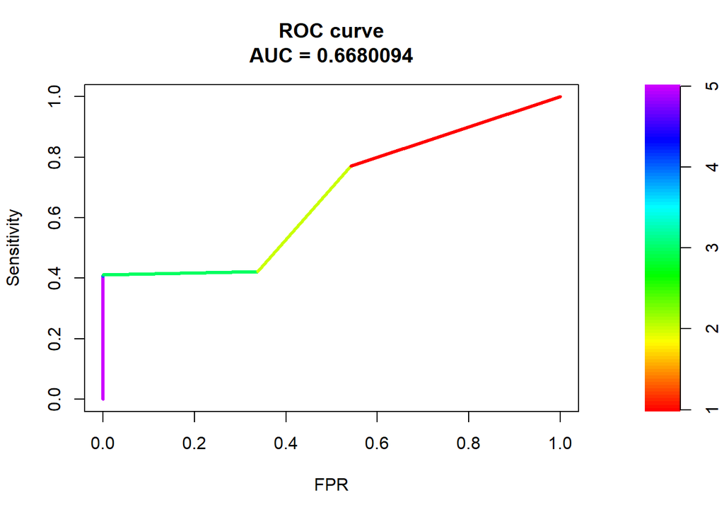

```r
tabla_test$pred_multilog = predict(mod_multi_log, newdata = tabla_test)

tabla_test<-tabla_test[which(!is.na(tabla_test$pred_multilog)),]

rocs = roc.curve(tabla_test$cat_mp10,tabla_test$pred_multilog, curve = TRUE)
plot(rocs)
```

```r
summary(mod_multi_log)
```

```
## Call:
## multinom(formula = cat_mp10 ~ O3 + CO + Tmedia + Tmax + Precipitaciones,
##     data = tabla_learn)
##
## Coefficients:
##                (Intercept)          O3         CO     Tmedia       Tmax
## ALERTA          -1.4663273 -0.12939606  0.9566586 -0.1620518  0.1017804
## BUENO            0.8511598  0.07448339 -0.9168332  0.1034386 -0.1070215
## PRE EMERGENCIA  -5.6847252 -0.12686625  0.6127530 -0.2761211  0.2705211
## PREALERTA       -3.9695813 -0.30879393 -0.4124993 -0.3781585  0.3019139
##                Precipitaciones
## ALERTA             -0.08822782
## BUENO               0.03173270
## PRE EMERGENCIA    -97.64829884
## PREALERTA        -255.14227250
##
## Std. Errors:
##                (Intercept)         O3        CO     Tmedia       Tmax
## ALERTA           0.7151975 0.04593010 0.2380970 0.06568302 0.04506438
## BUENO            0.6090012 0.03367879 0.2776299 0.06230131 0.04432901
## PRE EMERGENCIA   2.0903540 0.12144677 0.6134824 0.19549222 0.13273334
## PREALERTA        3.3481908 0.25300246 1.1283267 0.32333366 0.22521802
##                Precipitaciones
## ALERTA            6.643997e-02
## BUENO             2.814738e-02
## PRE EMERGENCIA    4.634174e-07
## PREALERTA         4.628550e-14
##
## Residual Deviance: 903.2099
## AIC: 951.2099
```

#### Datos Nulos o Faltantes

Los datos para algunas de las fechas no poseen todas las mediciones, por lo que se deben manejar los casos en que no hay valores en alguna columna. Los valores faltantes por cada columna son:

```r
na_count <-sapply(tabla, function(y) sum(length(which(is.na(y)))))
na_count <- data.frame(na_count)
na_count
```

```
##                 na_count
## Fecha                  0
## anno                   0
## mes                    0
## dia                    0
## O3                    20
## MP10                   3
## CO                     1
## SO2                  542
## MP25                 661
## NO2                  667
## Tmedia                 0
## Tmax                   0
## Precipitaciones        0
## cat_mp10               0
## cat_mp25               0
```

```r
try(tabla<-subset(tabla, select = -c(SO2,MP25,NO2)))
tabla[which(is.na(tabla$CO)),"CO"]<-median(tabla$CO, na.rm = TRUE)
tabla[which(is.na(tabla$MP10)),"MP10"]<-median(tabla$MP10, na.rm = TRUE)

lin_fit <-lm(O3~mes+dia+MP10+CO+Tmedia+Tmax+Precipitaciones,data = tabla ,na.action = "na.exclude")
tabla[which(is.na(tabla$O3)),"O3"]<-predict(lin_fit,tabla[which(is.na(tabla$O3)),c("mes","dia","MP10","CO","Tmedia","Tmax","Precipitaciones")])
rm(lin_fit)

tabla$cat_mp10<-as.factor(tabla$cat_mp10)
write.csv(tabla,"./tabla_imbalanced.csv", row.names = FALSE)

na_verify = sapply(tabla, function(y) sum(length(which(is.na(y)))))
na_verify <- data.frame(na_verify)
na_verify
```

```
##                 na_verify
## Fecha                   0
## anno                    0
## mes                     0
## dia                     0
## O3                      0
## MP10                    0
## CO                      0
## Tmedia                  0
## Tmax                    0
## Precipitaciones         0
## cat_mp10                0
## cat_mp25                0
```

#### Correlacion de los datos

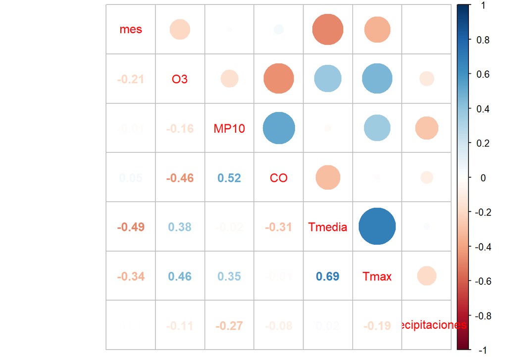

```r
tabla.cor <- cor(subset(tabla, select = -c(cat_mp10,cat_mp25,Fecha,anno,dia)), use = "pairwise.complete.obs" )
corrplot.mixed( tabla.cor )
```

### Balanceo de las clases

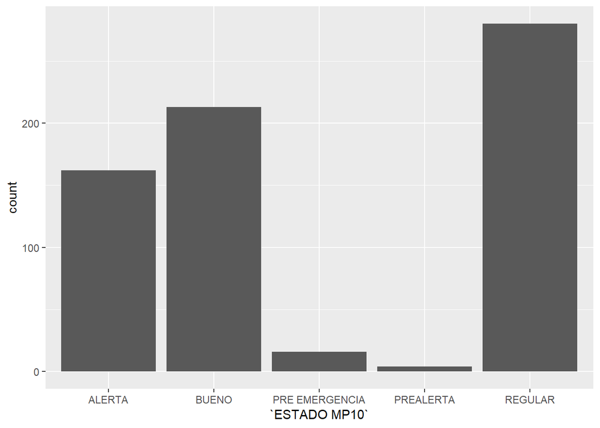

```r
ggplot(emergencia)+geom_bar(aes(`ESTADO MP10`))
```

```r
train_ind=sample(seq_len(nrow(tabla)),size = nrow(tabla)*0.7)
tabla_learn = tabla[train_ind,]
tabla_test = tabla[-train_ind,]

logit_balanced=multinom(cat_mp10~O3+CO+Tmedia+Tmax+Precipitaciones, data = tabla_learn)
```

## Feedback del Hito 1

En general las criticas de los compañeros dirijidas a la presentación son de la presentación misma; estos comentarios fueron tomados completamente, entre los que se encuentran tener un título más descriptivo del proyecto, agregar números a la diapositiva y tener objetivos más claramente definidos; esto último es una critica de la que somos bastante concientes ya que en la realidad no teníamos claro el objetivo final, sino que trabajamos con preguntas abiertas.

Además entre los comentarios hechos a los datos se nos sugiere *ignorar medidas nulas y errores de medición*, critica que tomamos completamente con la salvedad de que el como los ignoramos o eliminamos puede afectar nuestros resultados, ya que en general los datos faltan por periodos de tiempo bien definidos y el simplemente eliminar la columna o medidas muy extremas podrían hacernos perder información que puede ser relevante.